# India TB Pathways Analysis

Author

Jobert Richie Nansseu

# Description of the dataset: India TB Pathways Analysis

The India TB Pathways dataset is based on a study conducted in Vellore district, Tamil Nadu, India. It examines the pre-diagnostic costs and health-seeking behavior of 880 new adult pulmonary tuberculosis patients registered at Primary Health Centres (PHCs).

## Table showing the entire dataset

id

Sex

Age

Education

Employment

Alcohol

Smoking

WtinKgs

HtinCms

bmi

Diabetes

Form of TB

Chext Xray

first visit location

first visit cost

second visit location

second visit cost

third visit location

third visit cost

Health sys delay (in days)

Treatment initiation delay (in days)

[figure not shown]

## Spatial representation of the different districts of the Tamil Nadu State, India

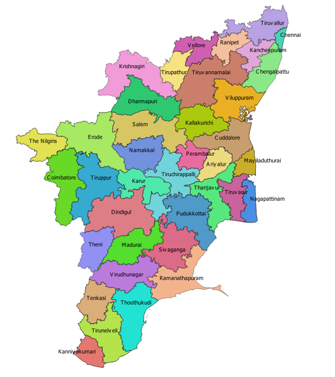

Tamil Nadu map

The following map represents the Tamil Nadu State located in the South of India. It comprises 38 districts and covers an area of 130 000 km square with around 83 million inhabitants. Vellore district is located in the Far-North segment of the State.

# Results of some bivariate analysis

## Distribution of age by sex

[interactive chart not shown]

From the graph we easily see that females seem younger than males. Indeed the males’ median age was 50 years (IQR: 39-60) vs 40 years (IQR: 26.5-49.5) for females.

## Education and employment

[interactive chart not shown]

The highest proportion of those currently employed were reported among patients of middle education level (86.1%) followed by Secondary level (85.2%). The highest proportion of those not working (currently unemployed) was recorded among the Higher Secondary level (36.5%).

## BMI and diabetes

[interactive chart not shown]

Patients with diabetes have higher BMI than those wothout, with a median of 19.3 (IQR: 16.5-21.7) vs 16.6 (IQR 15.1-23.3).

## Highlighting key numbers with inline code

Ages of participants ranged from 18 to 88 years, with a median of **48** years. The prevailing sex modality was “*Male*”. In addition, the education level modality that was mostly represented was “*No Education*”.